# Group 6 R Project

Beau Barber, Jadelyn Stewart, Katherine Vande Pol, and Rafael Gonzalez

10/12/2020

**Introduction**

Australia has one of the most variable climates of all countries in the world. One of the main causes of this phenomenon is due to the effect that mankind has had on global warming (Australian Government-Bureau of Meteorology, 2020), which is reflected in annual increases of more than one degree since 1910, with a peak in the 1950s. Within the same line of evidence (Potgieter, 2013), these fluctuations could also be attributed to a climatic phenomenon called El Niño, which is a climate phenomenon associated with the erratic heating of the eastern pacific continent every 3 to 7 years.

Furthermore, it can be seen that the mean temperature anomaly shows a turning point in the 1980s, accompanied by an irreversible increase in temperature recorded to date. The latter can be evidenced in the Bureau of Meteorology database (Australian Government-Bureau of Meteorology, 2020), where the last record of average mean temperature and mean maximum temperatures made in 2019 throughout the Australian territory, was 1.52°C and 2.09°C above average, respectively. Both measurements are above the average of temperatures recorded between the range of years 1961-1990, as well as higher than the previous peak, observed in 2013.

Regarding rainfall quantity, the fluctuations do not seem to follow the same linear pattern as those observed in temperature. They appear to be randomly dependent at each period, with a marked relationship with periods of extreme drought recorded by the Bureau of Meteorology (Australian Government-Bureau of Meteorology, 2020). However, 2019 also turned out to be a record year for droughts, registering a rainfall level of 277.6 mm, which was well below the previously recorded record (314.5 mm). In addition, 2019 showed an average rainfall of 40% lower than the average reported between 1961 and 1990 (Australian Government-Bureau of Meteorology, 2020).

Based on these reports, temperature seems to have been linearly increasing since the 1950s, while rainfall appears to follow a random pattern. Therefore, in this paper we propose to provide a statistical analysis of the changes in temperature and rainfall, reported in five cities across Australia, during the years of 2008 to 2018, as well as an extended analysis of Sidney and Perth (cities on the opposite sides of the continent) over the years of 1970 to 2018. Effects of city, month, and year will be evaluated singly and in various combinations for temperature (maximum and minimum) and rainfall.

**Data setup**

```r
rainfall <- readr::read_csv('https://raw.githubusercontent.com/rfordatascience/tidytuesday/master/data/2020/2020-01-07/rainfall.csv')
write.table(rainfall, "rainfall_overall_data.txt")
temperature <- readr::read_csv('https://raw.githubusercontent.com/rfordatascience/tidytuesday/master/data/2020/2020-01-07/temperature.csv')
write.table(temperature, "temperature_overall_data.txt")

head(rainfall)
```

```
## # A tibble: 6 x 11
##   station_code city_name  year month day   rainfall period quality   lat  long
##   <chr>        <chr>     <dbl> <chr> <chr>    <dbl>  <dbl> <chr>   <dbl> <dbl>
## 1 009151       Perth      1967 01    01          NA     NA <NA>    -32.0  116.
## 2 009151       Perth      1967 01    02          NA     NA <NA>    -32.0  116.
## 3 009151       Perth      1967 01    03          NA     NA <NA>    -32.0  116.
## 4 009151       Perth      1967 01    04          NA     NA <NA>    -32.0  116.
## 5 009151       Perth      1967 01    05          NA     NA <NA>    -32.0  116.
## 6 009151       Perth      1967 01    06          NA     NA <NA>    -32.0  116.
## # ... with 1 more variable: station_name <chr>
```

```r
head(temperature)
```

```
## # A tibble: 6 x 5
##   city_name date       temperature temp_type site_name
##   <chr>     <date>           <dbl> <chr>     <chr>
## 1 PERTH     1910-01-01        26.7 max       PERTH AIRPORT
## 2 PERTH     1910-01-02        27   max       PERTH AIRPORT
## 3 PERTH     1910-01-03        27.5 max       PERTH AIRPORT
## 4 PERTH     1910-01-04        24   max       PERTH AIRPORT
## 5 PERTH     1910-01-05        24.8 max       PERTH AIRPORT
## 6 PERTH     1910-01-06        24.4 max       PERTH AIRPORT
```

**Libraries**

Several R packages were used for the data analysis, and must be loaded into R before running the later code. The packages must be installed before they can be brought in using the “library” function, so be sure to install these packages if you have never done so before (ex: install.packages(“lsmeans”)).

```r
library(lmerTest)
library(lsmeans)
library(multcomp)
library(multcompView)
library(tidyverse)
library(lawstat)
library(doBy)
```

```r
library(ggplot2)
library(dplyr)
library(patchwork)
library(olsrr)
library(onewaytests)
library(tidytuesdayR)
library(olsrr)
library(onewaytests)
library(nortest)
```

**Filtering and data set combination**

The dates in the temperature and rainfall data sets are in different formats, so before the data sets can be combined, a column must be added to the rainfall data such that the date is all in one column as one date string:

```r
rainfall$date <- as.Date(paste(rainfall$year, "-", rainfall$month, "-", rainfall$day, sep = ""))
```

The city names in the two data sets are also capitalized differently, so the city names in the temperature data set must be replaced with such that they match (using the gsub option). The data sets also have differing date ranges, and must be filtered such that only the years of interest are included (Jan 1970 to Dec 2018). In addition, some cities are not included in both data sets, so only cities that are included in both were selected using the filter option as well.

```r
# Change the capitalization of city_names in temperature to match rainfall city_name case
temperature$city_name <- gsub("BRISBANE","Brisbane", temperature$city_name)
temperature$city_name <- gsub("CANBERRA","Canberra", temperature$city_name)
temperature$city_name <- gsub("MELBOURNE","Melbourne", temperature$city_name)
temperature$city_name <- gsub("PERTH","Perth", temperature$city_name)
temperature$city_name <- gsub("SYDNEY","Sydney", temperature$city_name)
head(temperature)
```

```
## # A tibble: 6 x 5
##   city_name date       temperature temp_type site_name
##   <chr>     <date>           <dbl> <chr>     <chr>
## 1 Perth     1910-01-01        26.7 max       PERTH AIRPORT
## 2 Perth     1910-01-02        27   max       PERTH AIRPORT
## 3 Perth     1910-01-03        27.5 max       PERTH AIRPORT
## 4 Perth     1910-01-04        24   max       PERTH AIRPORT
## 5 Perth     1910-01-05        24.8 max       PERTH AIRPORT
## 6 Perth     1910-01-06        24.4 max       PERTH AIRPORT
```

```r
# Filter data from 1970 to 2018, for cities that have BOTH rainfall and temperature data
rainfall_1 <-  rainfall %>%
  filter(date >= "1970-01-01", date <= "2018-12-31") %>%
  filter(city_name == "Brisbane" | city_name == "Canberra" | city_name == "Melbourne" | city_name == "Perth" | city_name == "Sydney")
head(rainfall_1)
```

```
## # A tibble: 6 x 12
##   station_code city_name  year month day   rainfall period quality   lat  long
##   <chr>        <chr>     <dbl> <chr> <chr>    <dbl>  <dbl> <chr>   <dbl> <dbl>
## 1 009151       Perth      1970 01    01           0     NA Y       -32.0  116.
## 2 009151       Perth      1970 01    02           0     NA Y       -32.0  116.
## 3 009151       Perth      1970 01    03           0     NA Y       -32.0  116.
## 4 009151       Perth      1970 01    04           0     NA Y       -32.0  116.
## 5 009151       Perth      1970 01    05           0     NA Y       -32.0  116.
## 6 009151       Perth      1970 01    06           0     NA Y       -32.0  116.
## # ... with 2 more variables: station_name <chr>, date <date>
```

```r
temp_1 <- temperature %>%
  filter(date >= "1970-01-01", date <= "2018-12-31") %>%
  filter(city_name == "Brisbane" | city_name == "Canberra" | city_name == "Melbourne" | city_name == "Perth" | city_name == "Sydney")
head(temp_1)
```

```
## # A tibble: 6 x 5
##   city_name date       temperature temp_type site_name
##   <chr>     <date>           <dbl> <chr>     <chr>
## 1 Perth     1970-01-01        35.6 max       PERTH AIRPORT
## 2 Perth     1970-01-02        26.4 max       PERTH AIRPORT
## 3 Perth     1970-01-03        25.9 max       PERTH AIRPORT
## 4 Perth     1970-01-04        26.9 max       PERTH AIRPORT
## 5 Perth     1970-01-05        28   max       PERTH AIRPORT
## 6 Perth     1970-01-06        25.7 max       PERTH AIRPORT
```

Now that the two data sets have the same cities, dates, and formats, they can be combined into one data frame using the merge option.

```r
combined <- merge(rainfall_1, temp_1, by = c("city_name", "date"))
write.table(combined, "overall_data.txt")
head(combined)
```

```
##   city_name       date station_code year month day rainfall period quality
## 1  Brisbane 1970-01-01       040383 1970    01  01       NA     NA    <NA>
## 2  Brisbane 1970-01-01       040383 1970    01  01       NA     NA    <NA>
## 3  Brisbane 1970-01-02       040383 1970    01  02       NA     NA    <NA>
## 4  Brisbane 1970-01-02       040383 1970    01  02       NA     NA    <NA>
## 5  Brisbane 1970-01-03       040383 1970    01  03       NA     NA    <NA>
## 6  Brisbane 1970-01-03       040383 1970    01  03       NA     NA    <NA>
##      lat   long                 station_name temperature temp_type
## 1 -27.51 153.05 Greenslopes Private Hospital        22.2       min
## 2 -27.51 153.05 Greenslopes Private Hospital        29.6       max
## 3 -27.51 153.05 Greenslopes Private Hospital        28.8       max
## 4 -27.51 153.05 Greenslopes Private Hospital        20.0       min
## 5 -27.51 153.05 Greenslopes Private Hospital        15.6       min
## 6 -27.51 153.05 Greenslopes Private Hospital        29.8       max
##       site_name
## 1 BRISBANE AERO
## 2 BRISBANE AERO
## 3 BRISBANE AERO
## 4 BRISBANE AERO
## 5 BRISBANE AERO
## 6 BRISBANE AERO
```

**Descriptive statistics**

For an initial look at the data for the parameters of interest, the mean, standard deviation, maximum, and minimum have been calculated below. These include the temperature (as the maximum and minimum) and rainfall for each city, and the temperature (as the maximum and minimum) and rainfall by month and by year for all cities.

```r
summaryBy(temperature ~ temp_type + city_name, data = combined,
  FUN = function(x) { c(average = mean(x, na.rm = T), standard_deviation = sd(x, na.rm = T), maximum = max(x, na.rm = T), minimum = min(x, na.rm = T)) } )
```

```
##    temp_type city_name temperature.average temperature.standard_deviation
## 1        max  Brisbane           25.240121                       3.510741
## 2        max  Canberra           21.031185                       7.023743
## 3        max Melbourne           19.815440                       6.004132
## 4        max     Perth           24.941518                       6.239365
## 5        max    Sydney           22.917476                       4.444622
## 6        min  Brisbane           15.599151                       5.112211
## 7        min  Canberra            6.550985                       6.340913
## 8        min Melbourne           11.337069                       4.054159
## 9        min     Perth           12.030093                       4.862006
## 10       min    Sydney           14.587261                       4.448508
##    temperature.maximum temperature.minimum
## 1                 40.2                11.8
## 2                 41.6                 4.1
## 3                 45.9                 6.5
## 4                 46.3                11.2
## 5                 45.8                10.0
## 6                 28.1                -1.3
## 7                 23.8                -8.7
## 8                 28.0                -1.0
## 9                 28.6                -1.9
## 10                27.6                 2.7
```

```r
summaryBy(rainfall ~ city_name, data = combined,
  FUN = function(x) { c(average = mean(x, na.rm = T), standard_deviation = sd(x, na.rm = T), maximum = max(x, na.rm = T), minimum = min(x, na.rm = T)) } )
```

```
##   city_name rainfall.average rainfall.standard_deviation rainfall.maximum
## 1  Brisbane         3.187658                   11.836907            240.4
## 2  Canberra         1.679824                    5.657261             87.6
## 3 Melbourne         1.779518                    5.074231            106.0
## 4     Perth         1.945919                    5.659263            132.4
## 5    Sydney         3.351009                   11.095330            327.6
##   rainfall.minimum
## 1                0
## 2                0
## 3                0
## 4                0
## 5                0
```

```r
summaryBy(rainfall ~ month, data = combined,
  FUN = function(x) { c(average = mean(x, na.rm = T), standard_deviation = sd(x, na.rm = T), maximum = max(x, na.rm = T), minimum = min(x, na.rm = T)) } )
```

```
##    month rainfall.average rainfall.standard_deviation rainfall.maximum
## 1     01         2.702128                   11.078282            240.4
## 2     02         3.091683                   11.839746            243.6
## 3     03         2.702295                   10.502531            207.4
## 4     04         2.521274                    9.458387            214.2
## 5     05         2.616944                    8.797466            227.0
## 6     06         3.201458                    8.949478            150.6
## 7     07         2.465630                    7.103031            209.6
## 8     08         2.281660                    8.183919            327.6
## 9     09         1.867344                    5.677352            107.2
## 10    10         2.190598                    7.338665            182.9
## 11    11         2.560849                    8.581611            234.6
## 12    12         2.377891                    8.014255            126.0
##    rainfall.minimum
## 1                 0
## 2                 0
## 3                 0
## 4                 0
## 5                 0
## 6                 0
## 7                 0
## 8                 0
## 9                 0
## 10                0
## 11                0
## 12                0
```

```r
summaryBy(temperature ~ month + temp_type, data = combined,
  FUN = function(x) { c(average = mean(x, na.rm = T), standard_deviation = sd(x, na.rm = T), maximum = max(x, na.rm = T), minimum = min(x, na.rm = T)) } )
```

```
##    month temp_type temperature.average temperature.standard_deviation
## 1     01       max           28.557454                       4.909345
## 2     01       min           18.368978                       3.687204
## 3     02       max           28.441331                       4.697833
## 4     02       min           18.455944                       3.528812
## 5     03       max           26.839551                       4.336982
## 6     03       min           16.912875                       3.703759
## 7     04       max           24.056541                       3.852053
## 8     04       min           13.889248                       3.911235
## 9     05       max           21.019827                       3.521159
## 10    05       min           11.129266                       3.912544
## 11    06       max           18.309198                       3.381633
## 12    06       min            8.896558                       3.646018
## 13    07       max           17.765812                       3.363513
## 14    07       min            7.848717                       3.589678
```

[output cut: 35 more lines]

```r
summaryBy(rainfall ~ year, data = combined,
  FUN = function(x) { c(average = mean(x, na.rm = T), standard_deviation = sd(x, na.rm = T), maximum = max(x, na.rm = T), minimum = min(x, na.rm = T)) } )
```

```
##    year rainfall.average rainfall.standard_deviation rainfall.maximum
## 1  1970         2.603927                    7.578240            126.0
## 2  1971         2.454895                    7.803468            140.0
## 3  1972         2.557099                    9.861496            182.9
## 4  1973         3.063598                   10.639544            209.6
## 5  1974         3.447295                   12.810720            240.4
## 6  1975         2.540896                    9.078890            198.2
## 7  1976         2.873898                    9.099462             99.2
## 8  1977         1.830621                    6.999373            113.6
## 9  1978         2.883472                    8.782690             98.6
## 10 1979         1.997429                    6.770114             74.6
## 11 1980         2.245378                    8.234895            149.2
## 12 1981         2.644089                    9.418506            154.0
## 13 1982         2.261479                    7.588206            124.0
## 14 1983         2.891179                    9.755274            131.0
```

[output cut: 85 more lines]

```r
summaryBy(temperature ~ year + temp_type, data = combined,
  FUN = function(x) { c(average = mean(x, na.rm = T), standard_deviation = sd(x, na.rm = T), maximum = max(x, na.rm = T), minimum = min(x, na.rm = T)) } )
```

```
##    year temp_type temperature.average temperature.standard_deviation
## 1  1970       max            22.80398                       5.543632
## 2  1970       min            12.60490                       5.044907
## 3  1971       max            22.63879                       5.388642
## 4  1971       min            12.70323                       5.113598
## 5  1972       max            23.29433                       5.720256
## 6  1972       min            12.86648                       4.979851
## 7  1973       max            23.16579                       5.746519
## 8  1973       min            13.52436                       5.010984
## 9  1974       max            22.68945                       5.533036
## 10 1974       min            12.99354                       4.978120
## 11 1975       max            23.01717                       5.447813
## 12 1975       min            13.12192                       4.757542
## 13 1976       max            23.05014                       5.539977
## 14 1976       min            13.20623                       4.925721
```

[output cut: 183 more lines]

**Temperature and rainfall plots**

For a further initial evaluation of the data, the temperature and rainfall have been plotted for each city across time. Since temperature is not an average, but is reported as the maximum and minimum for each date, the first step was to use the pivot_wider function to separate these into different columns such that they could be plotted separately.

```r
combined$date_monthly <- as.Date(paste(combined$year, "-", combined$month, "-", 1, sep = ""))
combined$date_yearly <- as.Date(paste(combined$year, "-", 1, "-", 1, sep = ""))

combined_wider <- na.omit(pivot_wider(data = combined, names_from = temp_type, values_from = temperature))
names(combined_wider)[names(combined_wider) == "max"] <- "max_temperature"
names(combined_wider)[names(combined_wider) == "min"] <- "min_temperature"
```

Next, the data were plotted by monthly average and yearly average.

```r
#Monthly Average Timeline
combined_avg_rt <- aggregate(. ~city_name + date_monthly, data = combined_wider[, c("rainfall","max_temperature","min_temperature","city_name","date_monthly")], mean)

p1 <- ggplot(data = combined_avg_rt) +
  geom_bar(mapping = aes(y = rainfall, x = date_monthly), size = 0.25, colour = "NA", fill = "dodgerblue",stat = "identity") +
  geom_point(mapping = aes(y = min_temperature/0.5, x = date_monthly), size = 0.05, alpha = 0.75, colour = "black") +
  geom_point(mapping = aes(y = max_temperature/0.5, x = date_monthly),size = 0.05, alpha = 0.75, colour = "red") +
  scale_y_continuous(name = ("Rainfall (blue)"), limit = c(-5,65),sec.axis = sec_axis(~.*0.5,name = "Temperature (Max=red, Min=black)")) +
  facet_grid(rows = vars(city_name))+
  scale_x_date(date_breaks = "years" , date_labels = "%Y") +
labs(x = "Year",title = "Average Monthly Rainfall and Max/Min Temperatures") +
  theme(axis.text.x = element_text(angle = 90)) +
  ggsave("montly_average_rainfall_temperatures_timeline.png")
#Yearly Average Timeline
combined_avg_rt <- aggregate(. ~city_name+date_yearly, data = combined_wider[, c("rainfall", "max_temperature", "min_temperature", "city_name", "date_yearly")], mean)

p1 <- ggplot(data = combined_avg_rt) +
  geom_bar(mapping = aes(y = rainfall, x = date_yearly), size = 0.05, colour = "NA", fill = "dodgerblue", stat = "identity") +
  geom_point(mapping = aes(y = min_temperature/0.75, x = date_yearly), size = 0.05, alpha = 0.75, colour = "black") +
  geom_point(mapping = aes(y = max_temperature/0.75, x = date_yearly), size = 0.05, alpha = 0.75, colour = "red") +
  scale_y_continuous(name = ("Rainfall (blue)"), limit = c(-5,65), sec.axis = sec_axis(~.*0.75, name = "Temperature (Max = red, Min = black)")) +
  facet_grid(rows = vars(city_name)) +
  scale_x_date(date_breaks = "years" , date_labels = "%Y") +
labs(x = "Year", title = "Average Yearly Rainfall and Max/Min Temperatures") +
  theme(axis.text.x = element_text(angle = 90)) +
  ggsave("yearly_average_rainfall_temperatures_timeline.png")
```

**Normality, HOV, ANOVA, and Linear Regression**

```r
Run_Normality_HOV_ANOVA_LinearReg <- function(y_input, factor_input, dataframe_name){
model <- lm(y_input ~ factor_input, data = dataframe_name)
ols_plot_resid_qq(model)
ols_plot_resid_fit(model)
#Anderson-Darling Normality Test
ad_out <- ad.test(model$residuals) #Normality
print(ad_out)
cat("\n-------------------------------\n\n")

#HOV Test: Brown-Forsythe test
res <- bf.test(rainfall ~ city_name, data = dataframe_name)

cat("\n-------------------------------\n-\n-\n-\n")
#ANOVA Table
anova(model)

#Significance of Slope Linear Regression
summary(model)
}
```

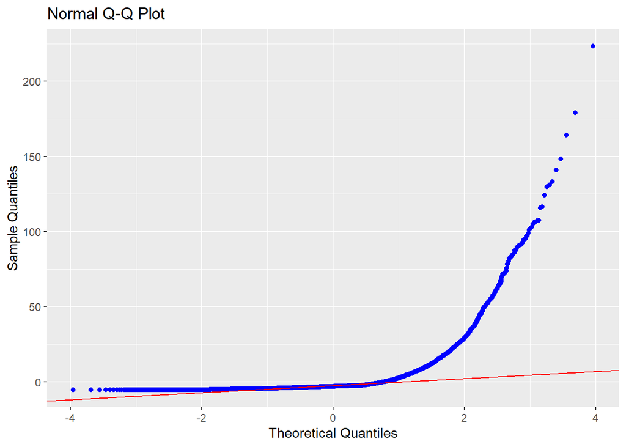

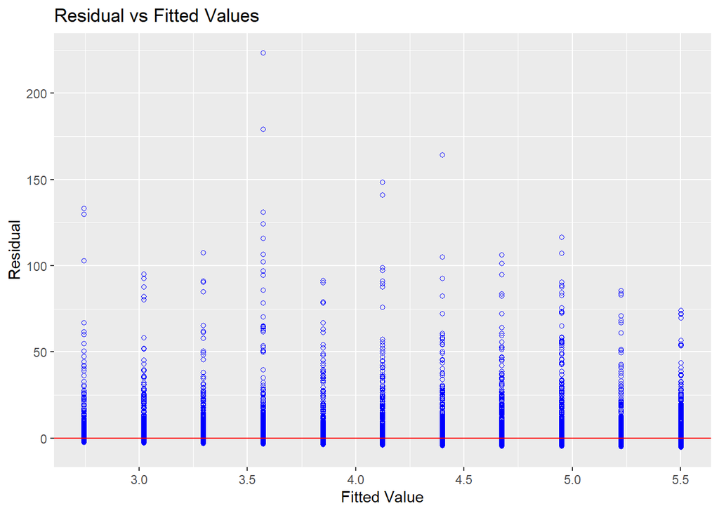

```
##
##  Anderson-Darling normality test
##
## data:  model$residuals
## A = 2293.8, p-value < 2.2e-16
##
##
## -------------------------------
##
##
##   Brown-Forsythe Test (alpha = 0.05)
## -------------------------------------------------------------
##   data : rainfall and city_name
##
##   statistic  : 57.95186
##   num df     : 4
##   denom df   : 8680.758
##   p.value    : 2.401516e-48
##
##   Result     : Difference is statistically significant.
## -------------------------------------------------------------
##
##
## -------------------------------
## -
## -
## -
```

```
##
## Call:
## lm(formula = y_input ~ factor_input, data = dataframe_name)
##
## Residuals:
##     Min      1Q  Median      3Q     Max
##  -5.502  -4.124  -3.102  -0.973 223.427
##
## Coefficients:
##              Estimate Std. Error t value Pr(>|t|)
## (Intercept)  559.0321    62.0170   9.014   <2e-16 ***
## factor_input  -0.2757     0.0308  -8.949   <2e-16 ***
## ---
## Signif. codes:  0 '***' 0.001 '**' 0.01 '*' 0.05 '.' 0.1 ' ' 1
##
## Residual standard error: 10.85 on 13165 degrees of freedom
## Multiple R-squared:  0.006047,   Adjusted R-squared:  0.005971
## F-statistic: 80.09 on 1 and 13165 DF,  p-value: < 2.2e-16
```

```r
combined_wider$month <- as.numeric(combined_wider$month)
combined_wider$year <- as.numeric(combined_wider$year)
combined_wider$city_name <- as.factor(combined_wider$city_name)

### Run the function with format as shown below:
### Run_Normality_HOV_ANOVA_LinearReg(dataframe$response_columnname,dataframe$group_columnname,dataframe)

#==== Looking at all cities from 2008 - 2018====
Current_period <- combined_wider %>% filter(date >= "2008-01-01", date <= "2018-12-31")

#Rainfall and Year
Run_Normality_HOV_ANOVA_LinearReg(Current_period$rainfall,Current_period$year,Current_period)
```

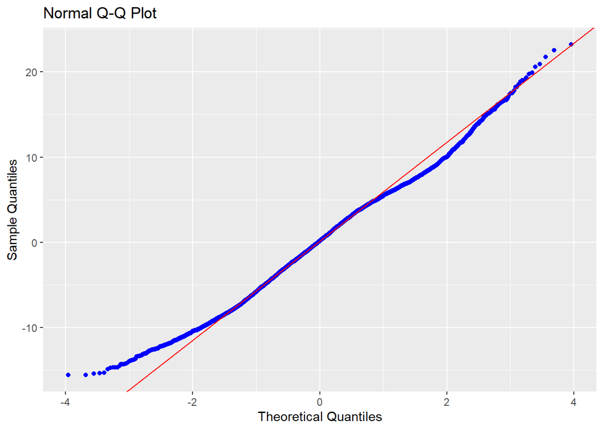

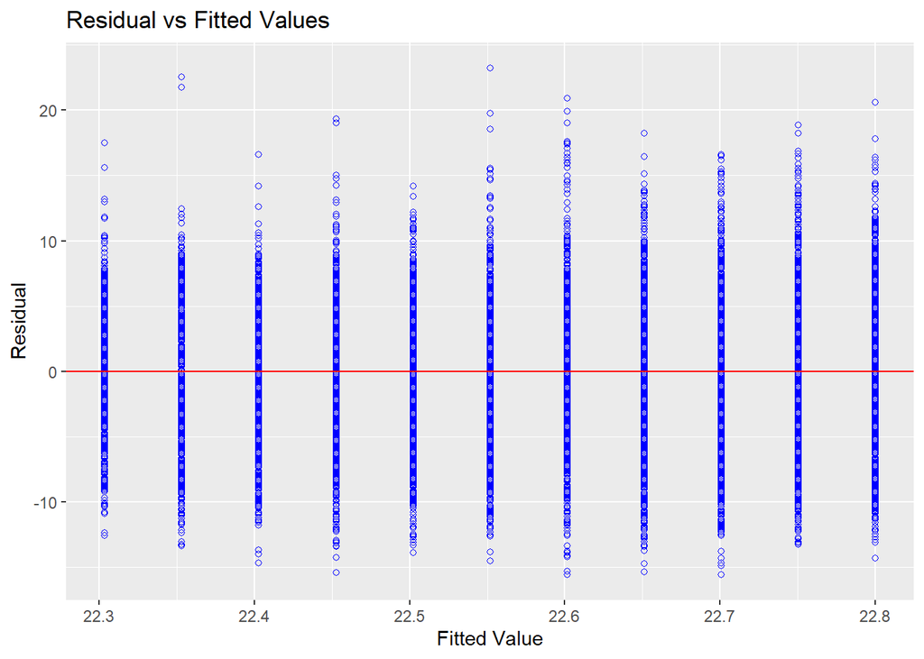

```
##
##  Anderson-Darling normality test
##
## data:  model$residuals
## A = 19.903, p-value < 2.2e-16
##
##
## -------------------------------
##
##
##   Brown-Forsythe Test (alpha = 0.05)
## -------------------------------------------------------------
##   data : rainfall and city_name
##
##   statistic  : 57.95186
##   num df     : 4
##   denom df   : 8680.758
##   p.value    : 2.401516e-48
##
##   Result     : Difference is statistically significant.
## -------------------------------------------------------------
##
##
## -------------------------------
## -
## -
## -
```

```
##
## Call:
## lm(formula = y_input ~ factor_input, data = dataframe_name)
##
## Residuals:
##      Min       1Q   Median       3Q      Max
## -15.6015  -3.8029   0.1496   4.0475  23.2482
##
## Coefficients:
##               Estimate Std. Error t value Pr(>|t|)
## (Intercept)  -77.39321   30.94653  -2.501  0.01240 *
## factor_input   0.04965    0.01537   3.230  0.00124 **
## ---
## Signif. codes:  0 '***' 0.001 '**' 0.01 '*' 0.05 '.' 0.1 ' ' 1
##
## Residual standard error: 5.414 on 13165 degrees of freedom
## Multiple R-squared:  0.0007919,  Adjusted R-squared:  0.000716
## F-statistic: 10.43 on 1 and 13165 DF,  p-value: 0.00124
```

```r
#Max Temperature and Years
Run_Normality_HOV_ANOVA_LinearReg(Current_period$max_temperature,Current_period$year,Current_period)
```

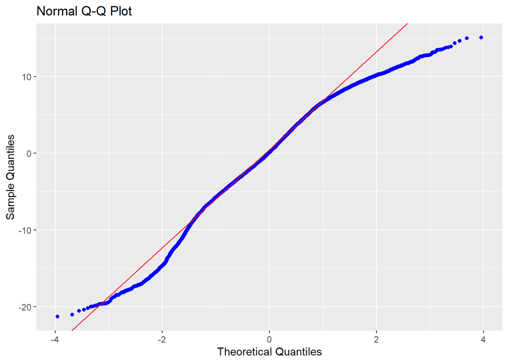

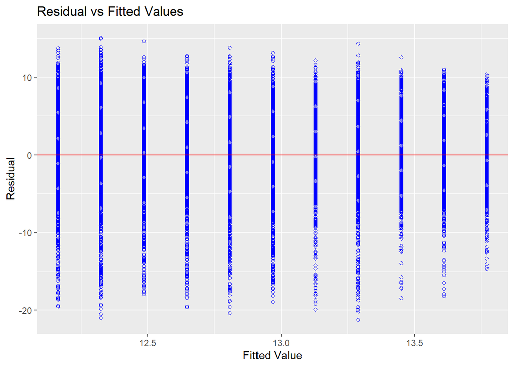

```
##
##  Anderson-Darling normality test
##
## data:  model$residuals
## A = 39.779, p-value < 2.2e-16
##
##
## -------------------------------
##
##
##   Brown-Forsythe Test (alpha = 0.05)
## -------------------------------------------------------------
##   data : rainfall and city_name
##
##   statistic  : 57.95186
##   num df     : 4
##   denom df   : 8680.758
##   p.value    : 2.401516e-48
##
##   Result     : Difference is statistically significant.
## -------------------------------------------------------------
##
##
## -------------------------------
## -
## -
## -
```

```
##
## Call:
## lm(formula = y_input ~ factor_input, data = dataframe_name)
##
## Residuals:
##      Min       1Q   Median       3Q      Max
## -21.2895  -3.8650   0.0711   4.7499  15.0744
##
## Coefficients:
##               Estimate Std. Error t value Pr(>|t|)
## (Intercept)  336.34677   35.05519   9.595   <2e-16 ***
## factor_input  -0.16065    0.01741  -9.226   <2e-16 ***
## ---
## Signif. codes:  0 '***' 0.001 '**' 0.01 '*' 0.05 '.' 0.1 ' ' 1
##
## Residual standard error: 6.133 on 13165 degrees of freedom
## Multiple R-squared:  0.006425,   Adjusted R-squared:  0.006349
## F-statistic: 85.13 on 1 and 13165 DF,  p-value: < 2.2e-16
```

```r
#Min Temperature and Years
Run_Normality_HOV_ANOVA_LinearReg(Current_period$min_temperature,Current_period$year,Current_period)
```

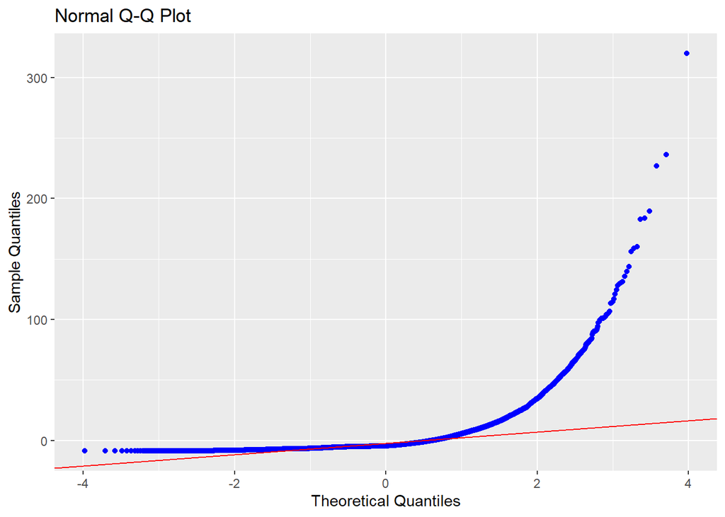

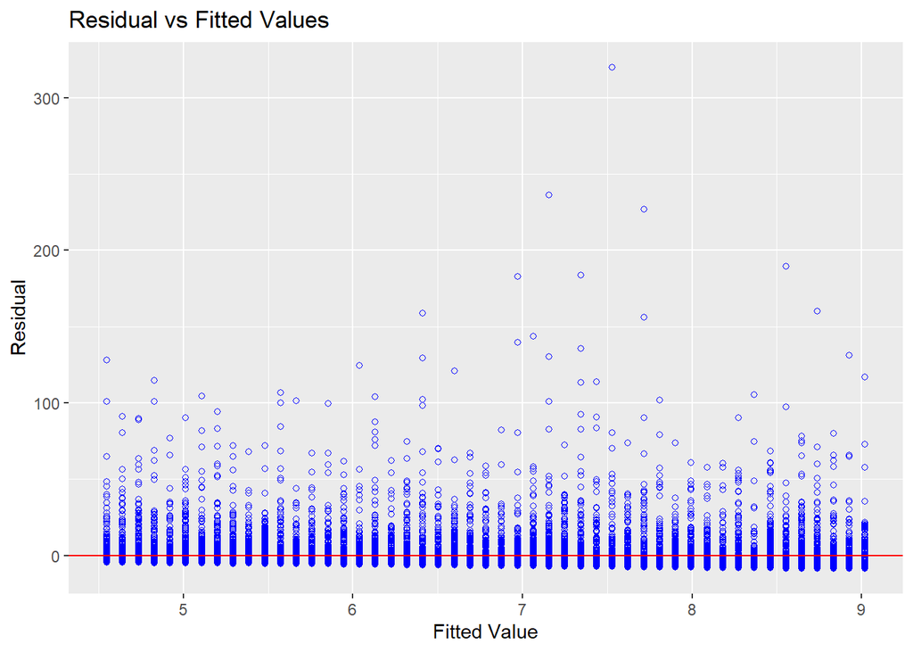

```
##
##  Anderson-Darling normality test
##
## data:  model$residuals
## A = 1840.8, p-value < 2.2e-16
##
##
## -------------------------------
##
##
##   Brown-Forsythe Test (alpha = 0.05)
## -------------------------------------------------------------
##   data : rainfall and city_name
##
##   statistic  : 0.880758
##   num df     : 1
##   denom df   : 14389.92
##   p.value    : 0.3480099
##
##   Result     : Difference is not statistically significant.
## -------------------------------------------------------------
##
##
## -------------------------------
## -
## -
## -
```

```
##
## Call:
## lm(formula = y_input ~ factor_input, data = dataframe_name)
##
## Residuals:
##    Min     1Q Median     3Q    Max
##  -8.72  -5.58  -4.51   0.71 320.07
##
## Coefficients:
##                Estimate Std. Error t value Pr(>|t|)
## (Intercept)  192.502978  14.678583   13.12   <2e-16 ***
## factor_input  -0.093139   0.007352  -12.67   <2e-16 ***
## ---
## Signif. codes:  0 '***' 0.001 '**' 0.01 '*' 0.05 '.' 0.1 ' ' 1
##
## Residual standard error: 12.89 on 14390 degrees of freedom
## Multiple R-squared:  0.01103,    Adjusted R-squared:  0.01096
## F-statistic: 160.5 on 1 and 14390 DF,  p-value: < 2.2e-16
```

```r
#==== Looking at Sydney and Perth only from 1970-2018 ====
sydney_and_perth_only <- combined_wider %>% filter(city_name == "Sydney" | city_name == "Perth")

#Rainfall and Year
Run_Normality_HOV_ANOVA_LinearReg(sydney_and_perth_only$rainfall,sydney_and_perth_only$year,sydney_and_perth_only)
```

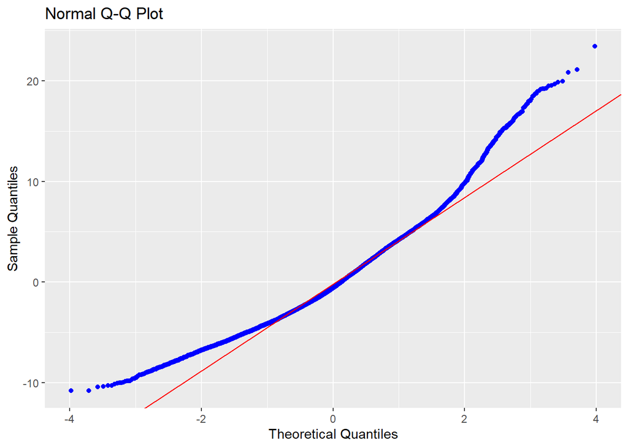

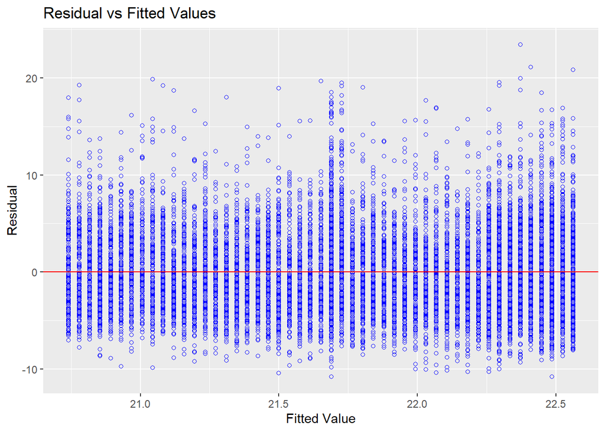

```
##
##  Anderson-Darling normality test
##
## data:  model$residuals
## A = 87.862, p-value < 2.2e-16
##
##
## -------------------------------
##
##
##   Brown-Forsythe Test (alpha = 0.05)
## -------------------------------------------------------------
##   data : rainfall and city_name
##
##   statistic  : 0.880758
##   num df     : 1
##   denom df   : 14389.92
##   p.value    : 0.3480099
##
##   Result     : Difference is not statistically significant.
## -------------------------------------------------------------
##
##
## -------------------------------
## -
## -
## -
```

```
##
## Call:
## lm(formula = y_input ~ factor_input, data = dataframe_name)
##
## Residuals:
##      Min       1Q   Median       3Q      Max
## -10.7895  -3.1205  -0.5827   2.6933  23.4276
##
## Coefficients:
##                Estimate Std. Error t value Pr(>|t|)
## (Intercept)  -53.992454   4.857235  -11.12   <2e-16 ***
## factor_input   0.037936   0.002433   15.59   <2e-16 ***
## ---
## Signif. codes:  0 '***' 0.001 '**' 0.01 '*' 0.05 '.' 0.1 ' ' 1
##
## Residual standard error: 4.265 on 14390 degrees of freedom
## Multiple R-squared:  0.01662,    Adjusted R-squared:  0.01655
## F-statistic: 243.2 on 1 and 14390 DF,  p-value: < 2.2e-16
```

```r
#Max Temperature and Years
Run_Normality_HOV_ANOVA_LinearReg(sydney_and_perth_only$max_temperature,sydney_and_perth_only$year,sydney_and_perth_only)
```

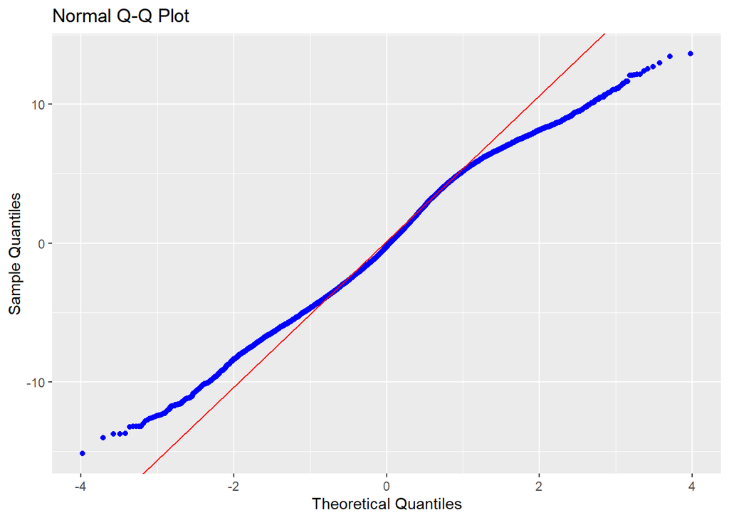

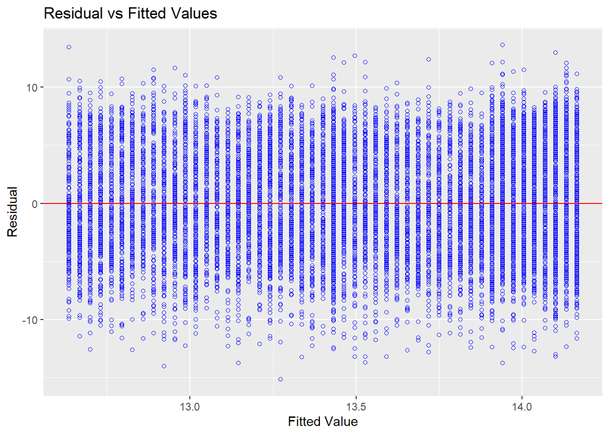

```
##
##  Anderson-Darling normality test
##
## data:  model$residuals
## A = 55.371, p-value < 2.2e-16
##
##
## -------------------------------
##
##
##   Brown-Forsythe Test (alpha = 0.05)
## -------------------------------------------------------------
##   data : rainfall and city_name
##
##   statistic  : 0.880758
##   num df     : 1
##   denom df   : 14389.92
##   p.value    : 0.3480099
##
##   Result     : Difference is not statistically significant.
## -------------------------------------------------------------
##
##
## -------------------------------
## -
## -
## -
```

```
##
## Call:
## lm(formula = y_input ~ factor_input, data = dataframe_name)
##
## Residuals:
##      Min       1Q   Median       3Q      Max
## -15.1728  -3.4316  -0.2594   3.6637  13.6586
##
## Coefficients:
##                Estimate Std. Error t value Pr(>|t|)
## (Intercept)  -50.090774   5.156029  -9.715   <2e-16 ***
## factor_input   0.031841   0.002582  12.330   <2e-16 ***
## ---
## Signif. codes:  0 '***' 0.001 '**' 0.01 '*' 0.05 '.' 0.1 ' ' 1
##
## Residual standard error: 4.527 on 14390 degrees of freedom
## Multiple R-squared:  0.01045,    Adjusted R-squared:  0.01039
## F-statistic:   152 on 1 and 14390 DF,  p-value: < 2.2e-16
```

```r
#Min Temperature and Years
Run_Normality_HOV_ANOVA_LinearReg(sydney_and_perth_only$min_temperature,sydney_and_perth_only$year,sydney_and_perth_only)
```

Note: Most of these analyses show that the residuals did not meet the assumptions of normality and homogeneity of variance. Ideally, a different analysis that does not rely on these assumptions would be used, or the data would be transformed such that the residuals conformed. However, that was outside of the scope of this initial analysis.

**Graphical presentation of data**

To further illustrate the effects of city, month, and year on temperature and rainfall, graphs have been created below.

```r
means <- combined_wider %>%
  group_by(max_temperature, city_name) %>%
  summarise(mean = mean(rainfall, na.rm = T))
```

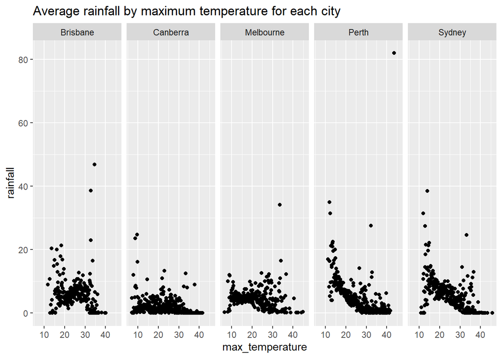

```r
ggplot(means, aes(x = max_temperature, y = mean)) +
  geom_point() +
  ylab("rainfall") + xlab("max_temperature") +
  facet_grid(~city_name) +
  ggtitle("Average rainfall by maximum temperature for each city") +
  ggsave("avg_rainfall_by_max_temp_for_each_city.png")
```

```r
means0 <- combined_wider %>%
  group_by(min_temperature, city_name) %>%
  summarise(mean = mean(rainfall, na.rm = T))
```

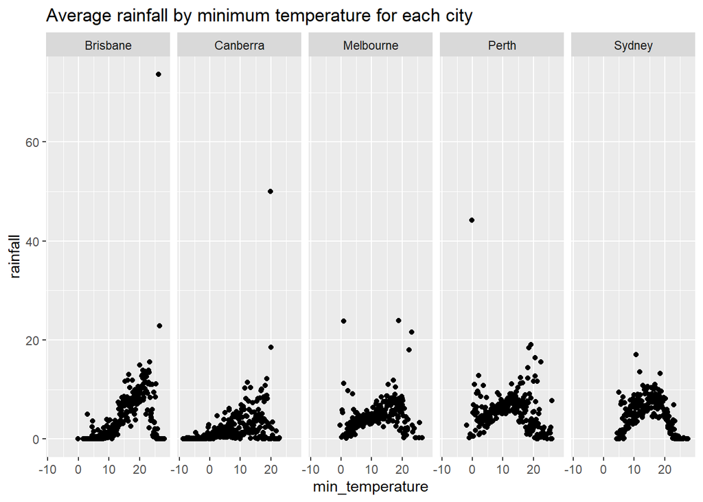

```r
ggplot(means0, aes(x = min_temperature, y = mean)) +
  geom_point() +
  ylab("rainfall") + xlab("min_temperature") +
  facet_grid(~city_name) +
  ggtitle("Average rainfall by minimum temperature for each city") +
  ggsave("avg_rainfall_by_min_temp_for_each_city.png")
```

```r
means1 <- combined %>%
  group_by(year) %>%
  summarise(mean = mean(rainfall, na.rm = T))
```

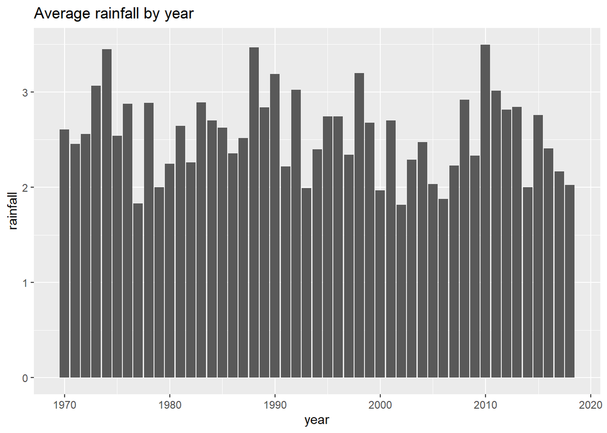

```r
ggplot(means1, aes(x = year, y = mean)) +
  geom_bar(position = position_dodge(), stat = "identity") +
  ylab("rainfall") + xlab("year") +
  ggtitle("Average rainfall by year") +
  ggsave("avg_rainfall_by_year.png")
```

```r
means2 <- combined_wider %>%
  group_by(year) %>%
  summarise(mean = mean(max_temperature, na.rm = T))
```

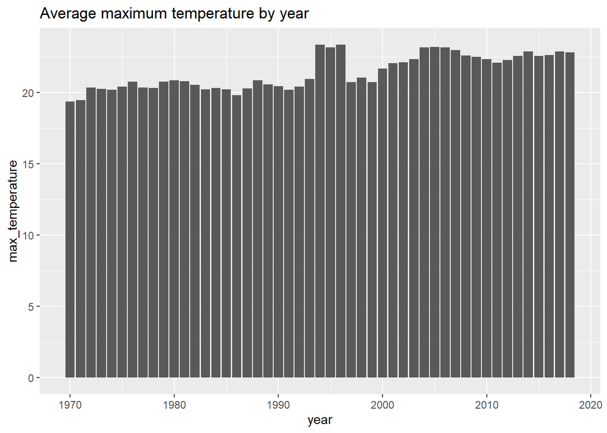

```r
ggplot(means2, aes(x = year, y = mean)) +
  geom_bar(position = position_dodge(), stat = "identity") +
  ylab("max_temperature") + xlab("year") +
  ggtitle("Average maximum temperature by year") +
  ggsave("avg_max_temp_by_year.png")
```

```r
means3 <- combined_wider %>%
  group_by(year) %>%
  summarise(mean = mean(min_temperature, na.rm = T))
```

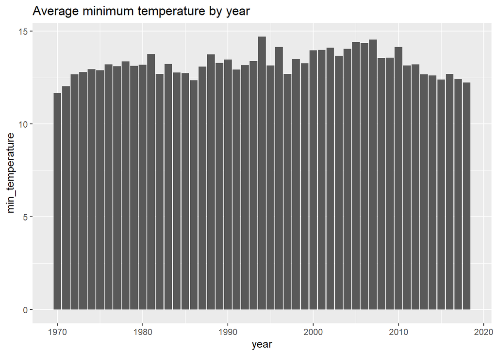

```r
ggplot(means3, aes(x = year, y = mean)) +
  geom_bar(position = position_dodge(), stat = "identity") +
  ylab("min_temperature") + xlab("year") +
  ggtitle("Average minimum temperature by year") +
  ggsave("avg_min_temp_by_year.png")
```

```r
means4 <- combined %>%
  group_by(month) %>%
  summarise(mean = mean(rainfall, na.rm = T))
```

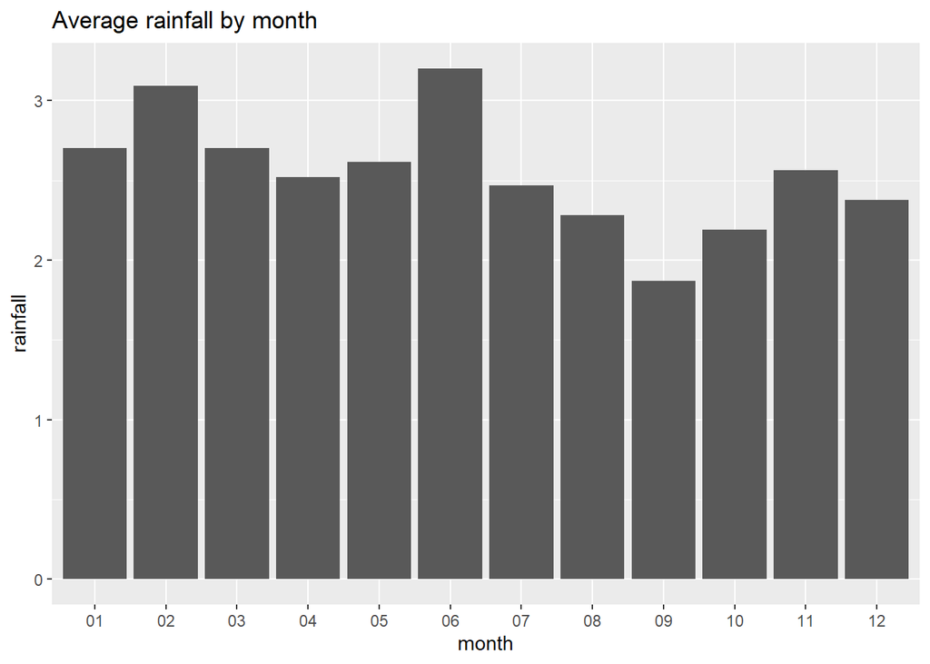

```r
ggplot(means4, aes(x = month, y = mean)) +
  geom_bar(position = position_dodge(), stat = "identity") +
  ylab("rainfall") + xlab("month") +
  ggtitle("Average rainfall by month") +
  ggsave("avg_rainfall_by_month.png")
```

```r
means5 <- combined_wider %>%
  group_by(month) %>%
  summarise(mean = mean(max_temperature, na.rm = T))
```

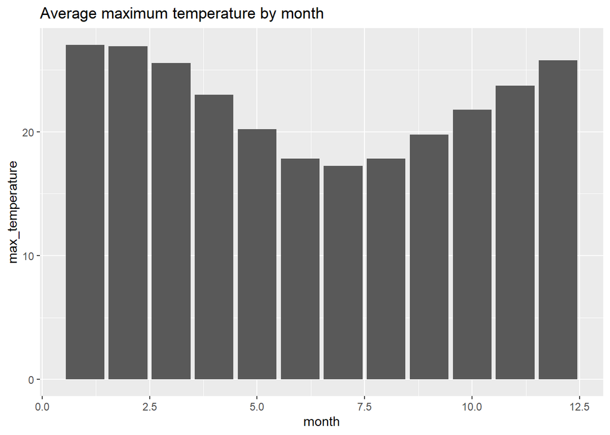

```r
ggplot(means5, aes(x = month, y = mean)) +
  geom_bar(position = position_dodge(), stat = "identity") +
  ylab("max_temperature") + xlab("month") +
  ggtitle("Average maximum temperature by month") +
  ggsave("avg_max_temp_by_month.png")
```

```r
means6 <- combined_wider %>%
  group_by(month) %>%
  summarise(mean = mean(min_temperature, na.rm = T))
```

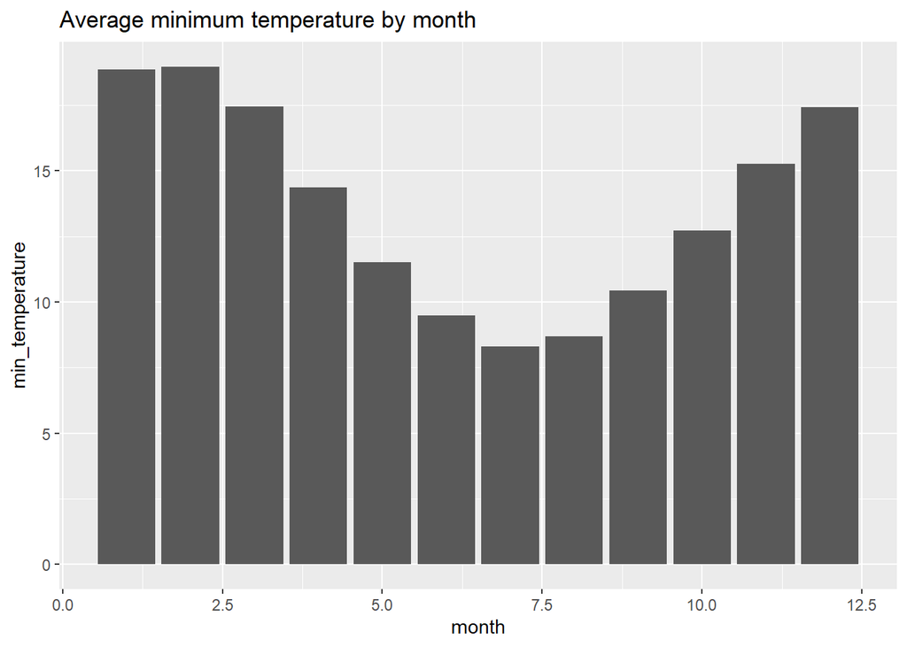

```r
ggplot(means6, aes(x = month, y = mean)) +
  geom_bar(position = position_dodge(), stat = "identity") +
  ylab("min_temperature") + xlab("month") +
  ggtitle("Average minimum temperature by month") +
  ggsave("avg_min_temp_by_month.png")
```

```r
means7 <- combined %>%
  group_by(city_name, year) %>%
  summarise(mean = mean(rainfall, na.rm = T))
```

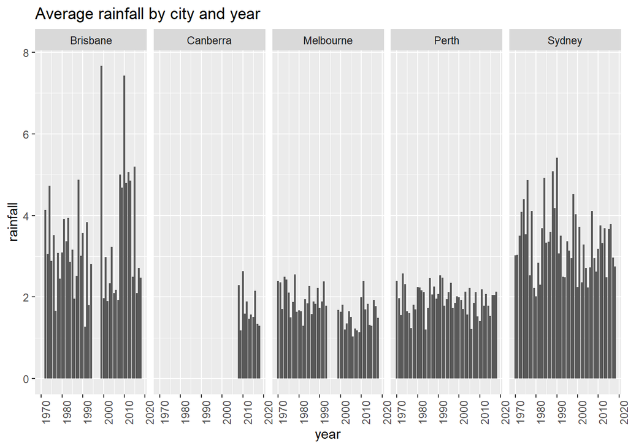

```r
ggplot(means7, aes(x = year, y = mean)) +
  geom_bar(position = position_dodge(), stat = "identity") +
  ylab("rainfall") + xlab("year") +
  facet_grid(~city_name) +
  theme(axis.text.x = element_text(angle = 90)) +
  ggtitle("Average rainfall by city and year") +
  ggsave("avg_rainfall_by_city_and_year.png")
```

```r
means8 <- combined_wider %>%
  group_by(city_name, year) %>%
  summarise(mean = mean(max_temperature, na.rm = T))
```

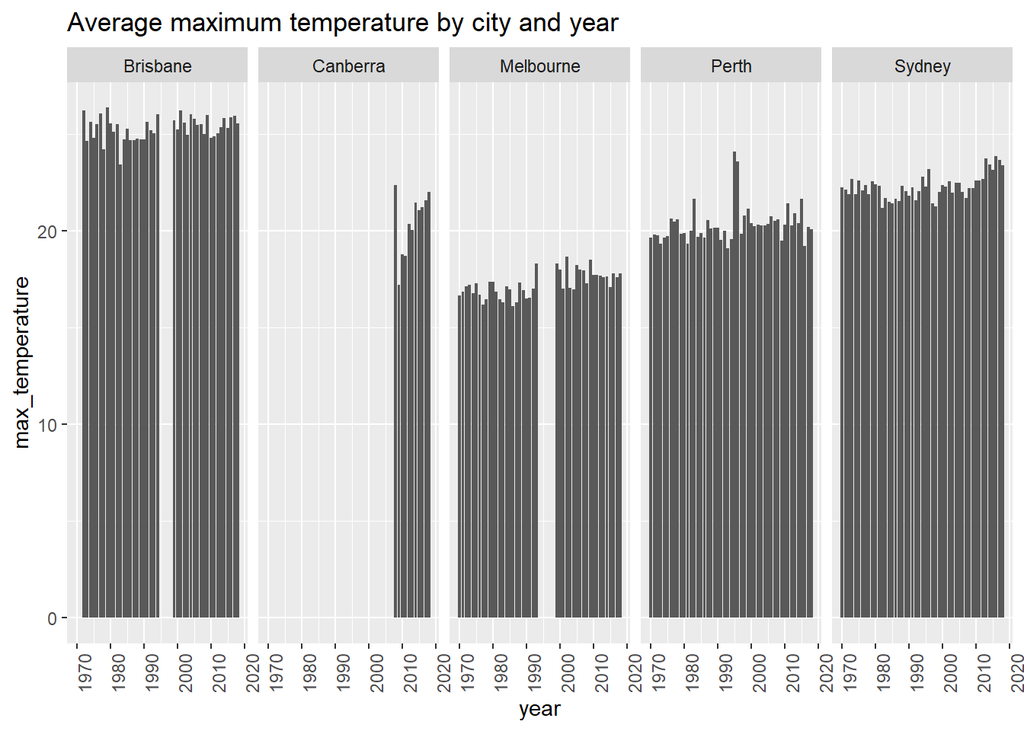

```r
ggplot(means8, aes(x = year, y = mean)) +
  geom_bar(position = position_dodge(), stat = "identity") +
  ylab("max_temperature") + xlab("year") +
  facet_grid(~city_name) +
  theme(axis.text.x = element_text(angle = 90)) +
  ggtitle("Average maximum temperature by city and year") +
  ggsave("avg_max_temp_by_city_and_year.png")
```

```r
means9 <- combined_wider %>%
  group_by(city_name, year) %>%
  summarise(mean = mean(min_temperature, na.rm = T))
```

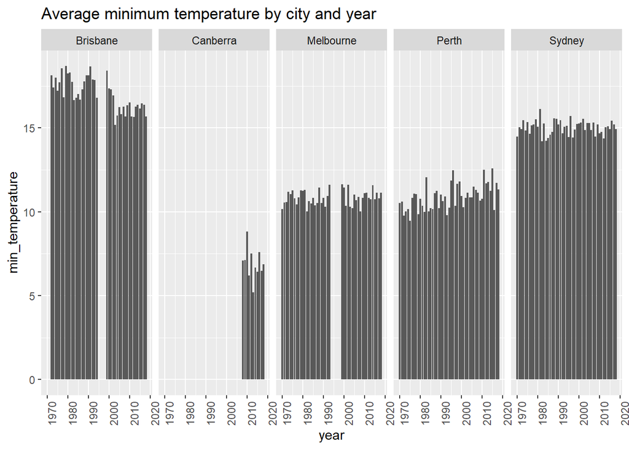

```r
ggplot(means9, aes(x = year, y = mean)) +
  geom_bar(position = position_dodge(), stat = "identity") +
  ylab("min_temperature") + xlab("year") +
  facet_grid(~city_name) +
  theme(axis.text.x = element_text(angle = 90)) +
  ggtitle("Average minimum temperature by city and year") +
  ggsave("avg_min_temp_by_city_and_year.png")
```

```r
write.table(means, "rainfall means by max_temperature, city_name.txt")
write.table(means0, "rainfall means by min_temperature, city_name.txt")
write.table(means1, "rainfall means by year.txt")
write.table(means2, "max_temperature means by year.txt")
write.table(means3, "min_temperature means by year.txt")
write.table(means4, "rainfall means by month.txt")
write.table(means5, "max_temperature means by month.txt")
write.table(means6, "min_temperature means by month.txt")
write.table(means7, "rainfall means by city_name, year.txt")
write.table(means8, "max_temperature means by city_name, year.txt")
write.table(means9, "min_temperature means by city_name, year.txt")
```

**Results and Discussion**

From 1970 to 2018, Brisbane had the highest average temperature (25.2 C) and the lowest standard deviation (3.5). However, the highest maximum temperature of 46.3 C was in Perth. The lowest minimum temperature was found in Canberra at -8.7 C. Sydney had the highest average rainfall (3.4 mm) and the highest maximum rainfall (327.6 mm) from 1970 to 2018.Sydney’s rainfall had a standard deviation of 11.1 mm, the second highest in the group. All locations had a minimum rainfall of 0 during this time period.

There were significant results in analyses from 2008 – 2018 of rainfall and years (P-Value <0.001), max temperature and years (P-Value 0.001), and min temperature and years (P-Value <0.001).

The climate change analysis looking at only the cities of Perth and Sydney showed that results were significant for rainfall and years (P-Value <0.001), max temperature and years (P-Value <0.001), and min temperature and years (P-Value <0.001).

**References**

Potgieter, A., Meinke, H., Doherty, A., Sadras, V. O., Hammer, G., Crimp, S., & Rodriguez, D. (2013). Spatial impact of projected changes in rainfall and temperature on wheat yields in Australia. Climatic Change, 117(1-2), 163-179.

Australian Government-Bureau of Meteorology. (2020, 9 January). Annual climate statement 2019. http://www.bom.gov.au/climate/current/annual/aus/#tabs=Temperature